# Project_khan

Firasath Ali Khan

April 27, 2017

CARDIOTOCOGRAPHY : Evaluating fetal status to avoid surgical intervention.

Goal : An improper CTG measure could suggest possibility of having to deliver through Caesarean section. Hence the goal of these models is to ensure accurate prediction of fetal well-being the CTG needs to be appropriately interpreted.

Source: http://archive.ics.uci.edu/ml/datasets/Cardiotocography?iframe=true&width=100%&height=100%

The dataset includes a total of 2126 samples and 40 attributes. the variable we are mst interestd is the NSP where the results of the output given by CTG were classified by 3 expert obstreticians who based their diagoses on below 21 variables. I have only included this 21 variables in my dataset for model evaluation. 1. LB Baseline value.  
2. AC accelerations.  
3. FM foetal movement.  
4. UC uterine contractions. 5. DL light decelerations.  
6. DS severe decelerations.  
7. DP Prolonged decelerations.  
8. ASTV percentage of time with abnormal short term variability.  
9. MSTV mean value of short term variability.  
10. ALTV percentage of time with abnormal long term variability.  
11. MLTV mean value of long term variability.  
12. Width histogram width. 13. Min low freq. of the histogram. 14. Max high freq. of the histogram. 15. Nmax number of histogram peaks. 16. Nzeros number of histogram zeros. 17. Mode histogram mode. 18. Mean histogram mean. 19. Median histogram median. 20. Variance histogram variance. 21. Tendency histogram tendency: -1=left asymmetric; 0=symmetric; 1=right asymmetric. 22. NSP Normal=1; Suspect=2; Pathologic=3.

Abstract: Asessing cardiotocography is crucial in that it leads to identifying fetuses which suffer from lack of oxygen, i.e. hypoxia. This situation is defined as fetal distress and requires fetal intervention in order to prevent fetus death or other neurological disease caused by hypoxia. Different Models were created and based on different metrics Bagging model was choosen as the recommended model to predict the outcome of the readings provided by the CTG machine.

Models Created : 1) Decision tree using rpart and caret. 2) Multinomial Regression. 3) Bagging Model. 4) Random Forest Model.

I have randomized the observations and took 1700 observations(80% of the dataset) in my Training set and the remaining observations in my Test set.

```r
set.seed(123)
ctg_random1 <- ctg1[order(runif(2126)), ] # randomize observations
ctg_rand1 <- sample(1:2126, 1700) # 1700 observations in training and the rest in test set. An 80-20 split of the dataset.
train1 <- ctg1[ctg_rand1,]
test1  <- ctg1[-ctg_rand1,]
```

First Model Using rpart and caret package. Decision tree using gini. The decision tree shows Importance of variables. The Variable on the top is highly important and the as you go lower the importnace of variables also lowers. This process repeats untill a leaf node/ end result is reached.

I am making the model Using train set and fitting it on the test set, I have Inclued the Accuracy, sensitivity and specificity for convinience.

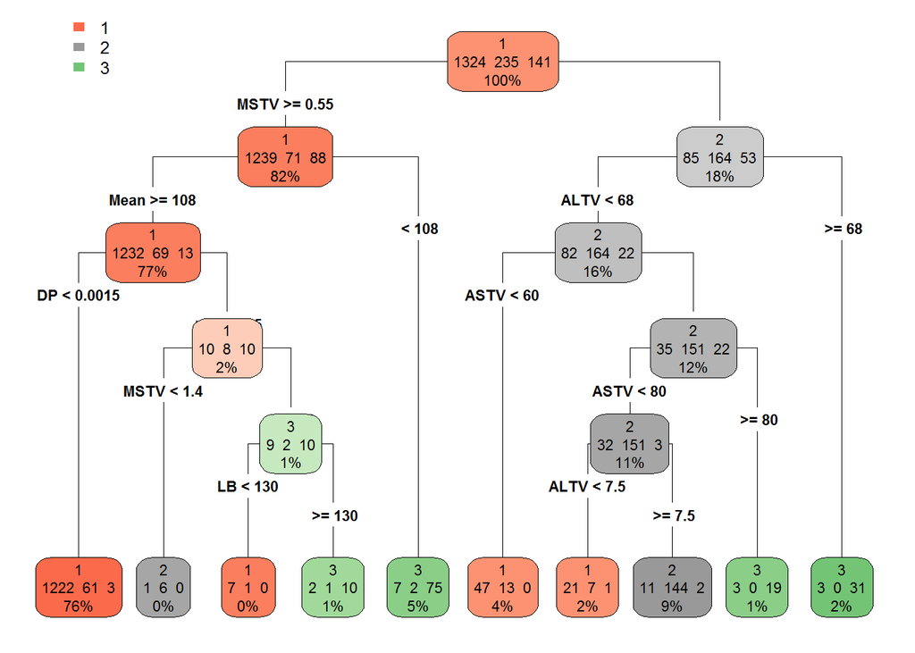

```r
set.seed(123)
NSP.rpart1<-rpart(train1$NSP ~ ., method="class", parms=list(split="gini"), data=train1)
rpart.plot(NSP.rpart1, type=4, extra=101, cex = 0.7)
```

[figure not shown]

```r
NSP.party1<-as.party(NSP.rpart1)
plot(NSP.party1)
```

```r
#Validating

actual1 <- test1$NSP
NSP_predicted1 <- predict(NSP.rpart1, newdata=test1, type="class")
NSP_results.matrix1 <- confusionMatrix(NSP_predicted1, actual1, positive="yes")
print(NSP_results.matrix1) # Accuracy-90.38, Sensitivity-96.98 and specificity 68.42
```

```
## Confusion Matrix and Statistics
##
##           Reference
## Prediction   1   2   3
##          1 321  29   1
##          2   4  31   1
##          3   6   0  33
##
## Overall Statistics
##
##                Accuracy : 0.9038
##                  95% CI : (0.8717, 0.93)
##     No Information Rate : 0.777
##     P-Value [Acc > NIR] : 5.087e-12
##
##                   Kappa : 0.7172
##  Mcnemar's Test P-Value : 3.160e-05
##
## Statistics by Class:
##
##                      Class: 1 Class: 2 Class: 3
## Sensitivity            0.9698  0.51667  0.94286
## Specificity            0.6842  0.98634  0.98465
## Pos Pred Value         0.9145  0.86111  0.84615
## Neg Pred Value         0.8667  0.92564  0.99483
## Prevalence             0.7770  0.14085  0.08216
## Detection Rate         0.7535  0.07277  0.07746
## Detection Prevalence   0.8239  0.08451  0.09155
## Balanced Accuracy      0.8270  0.75150  0.96376
```

```r
#1-sum(diag(NSP_results.matrix1))/sum(NSP_results.matrix1)
```

I have validated my decision tree using K-fold cross validation. Doing this I can know the appropriate coplexity parameter that can be used to prune the tree which will Improve the performance of the model. Here the cp-value that i have used to prune the decision tree is 0.01152482, Although it did not help in improving the performance of the model.

Validating the Decision Tree using k-fold cross validation

```r
set.seed(123)
cvCtrl <- trainControl(method="cv", number=10) #Here I am using 10 folds to pick a Decision tree that I judge is best suitable.

ctg.caret.10folds<-train(NSP ~., data=train1, method="rpart", metric="Accuracy", tuneLength=10, trControl=cvCtrl)

#Here I am using Accuracy  as my metric.

ctg.caret.10folds
```

```
## CART
##
## 1700 samples
##   21 predictor
##    3 classes: '1', '2', '3'
##
## No pre-processing
## Resampling: Cross-Validated (10 fold)
## Summary of sample sizes: 1529, 1531, 1529, 1529, 1530, 1530, ...
## Resampling results across tuning parameters:
##
##   cp           Accuracy   Kappa
##   0.000000000  0.9165207  0.7721102
##   0.005319149  0.9112230  0.7537165
##   0.007978723  0.9112127  0.7497723
##   0.009751773  0.9141470  0.7545302
##   0.011524823  0.9188668  0.7606940
##   0.037234043  0.9159222  0.7538321
##   0.050531915  0.9029738  0.7206827
##   0.086436170  0.8764576  0.6563813
##   0.180851064  0.8364705  0.5240008
##   0.210106383  0.7870822  0.1270645
##
## Accuracy was used to select the optimal model using  the largest value.
## The final value used for the model was cp = 0.01152482.
```

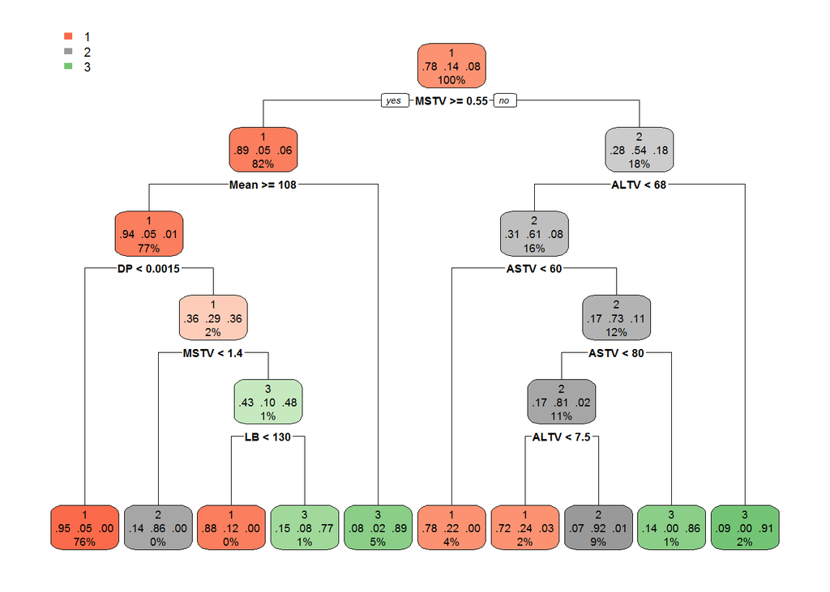

```r
ctg.rpart.pruned<-prune(NSP.rpart1, cp=0.01152482) #prunning of the decision tree is done using the recommended cp value.The complexity parameter (cp) is used to control the size of the decision tree and to select the optimal tree size.
rpart.plot(ctg.rpart.pruned)
```

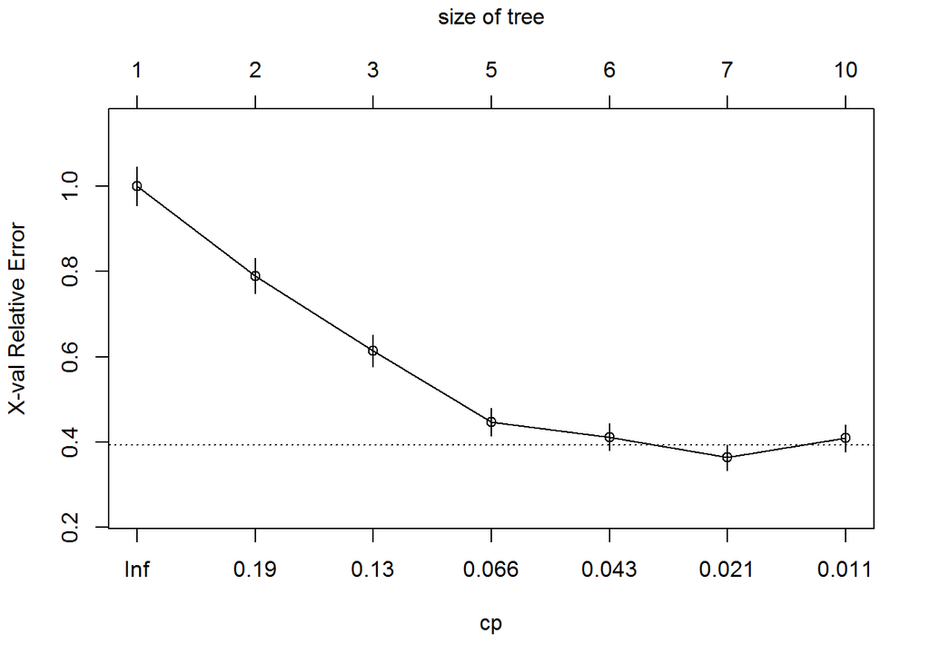

```r
plotcp(ctg.rpart.pruned)
```

```r
#validate

actual <- test1$NSP
ctg_predicted.10fold <- predict(ctg.rpart.pruned, newdata=test1, type="class")
ctg_results.matrix.10fold <- confusionMatrix(ctg_predicted.10fold, actual, positive="yes")
print(ctg_results.matrix.10fold) #Accuracy-90.38, Sensitivity-96.98 and specificity 68.42
```

```
## Confusion Matrix and Statistics
##
##           Reference
## Prediction   1   2   3
##          1 321  29   1
##          2   4  31   1
##          3   6   0  33
##
## Overall Statistics
##
##                Accuracy : 0.9038
##                  95% CI : (0.8717, 0.93)
##     No Information Rate : 0.777
##     P-Value [Acc > NIR] : 5.087e-12
##
##                   Kappa : 0.7172
##  Mcnemar's Test P-Value : 3.160e-05
##
## Statistics by Class:
##
##                      Class: 1 Class: 2 Class: 3
## Sensitivity            0.9698  0.51667  0.94286
## Specificity            0.6842  0.98634  0.98465
## Pos Pred Value         0.9145  0.86111  0.84615
## Neg Pred Value         0.8667  0.92564  0.99483
## Prevalence             0.7770  0.14085  0.08216
## Detection Rate         0.7535  0.07277  0.07746
## Detection Prevalence   0.8239  0.08451  0.09155
## Balanced Accuracy      0.8270  0.75150  0.96376
```

It is used to predict the nominal outputs. Here As I have three levels in my target variable 1=Normal, 2=Suspect and 3=Pathologic, I am setting 1 as my reference level which will be used to compare other levels of my target variable.